# Air Pollution Data Availability

Eric Bailey

March 25, 2016

## Data Source

U.S. EPA’s Air Quality System website was used to obtain a list of all air quality monitors in the country. This file was obtained from the following location: http://aqsdr1.epa.gov/aqsweb/aqstmp/airdata/aqs_monitors.zip most recently on March 24, 2016. The data was then processed using the `R` programming language to subset and visualize the parameters of interest for the State of Indiana. The remainder of this document will outline the available data.

## Data Cleaning and Filtering

The raw dataset downloaded from U.S. EPA contained 300400 records. Each record represents a monitor with data in AQS. Basic cleanup of this data was done, including ensuring that date columns were formatted as dates and an index column was created by concatenating the `State.Code`, `County.Code`, `Site.Number`, and `POC` columns.

Next, any rows with missing date ranges were removed, as well as any rows where the `Last.Sample.Date` was before January 1, 1999. Lastly, the dataset was reduced to only records from Indiana (`State.Code == 18`). This filtering left 5685 rows of data.

### Ozone (44201)

There are 60 ozone monitors in Indiana that have been active at some point between 1999 and 2015. Of these, 46 were active as of the end of 2015 and 22 have been active during the entire period covered by this project (1999-2015).

Below is a plot illustrating ozone data coverage, by monitor, for all monitors that collected ozone data during the period of interest.

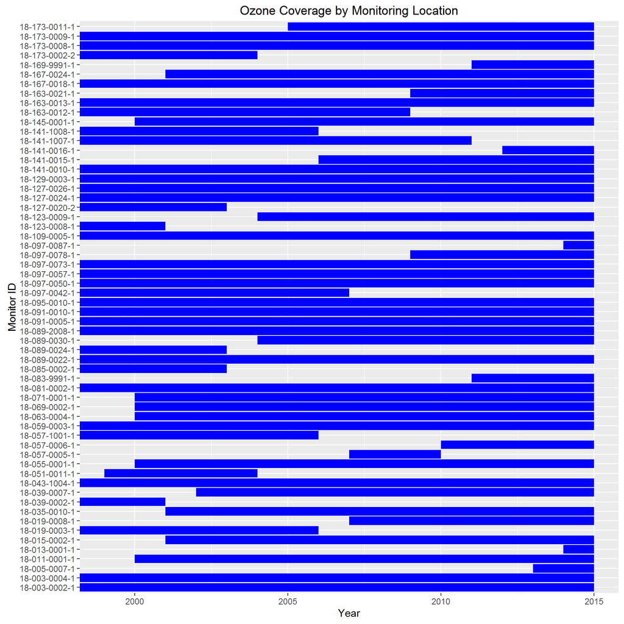

Many EPA air pollutant monitors are placed relative to specific sources and so are not representative of general concentrations or population exposures. Below is a table showing the reported purpose of ozone monitors in Indiana.

| Monitoring Objective | Count |
| --- | --- |
| GENERAL/BACKGROUND; POPULATION EXPOSURE | 1 |
| HIGHEST CONCENTRATION | 8 |
| HIGHEST CONCENTRATION; POPULATION EXPOSURE | 33 |
| HIGHEST CONCENTRATION; UPWIND BACKGROUND | 2 |
| MAX OZONE CONCENTRATION | 2 |
| POPULATION EXPOSURE | 8 |
| POPULATION EXPOSURE; UPWIND BACKGROUND | 2 |
| UNKNOWN | 3 |
| UPWIND BACKGROUND | 1 |

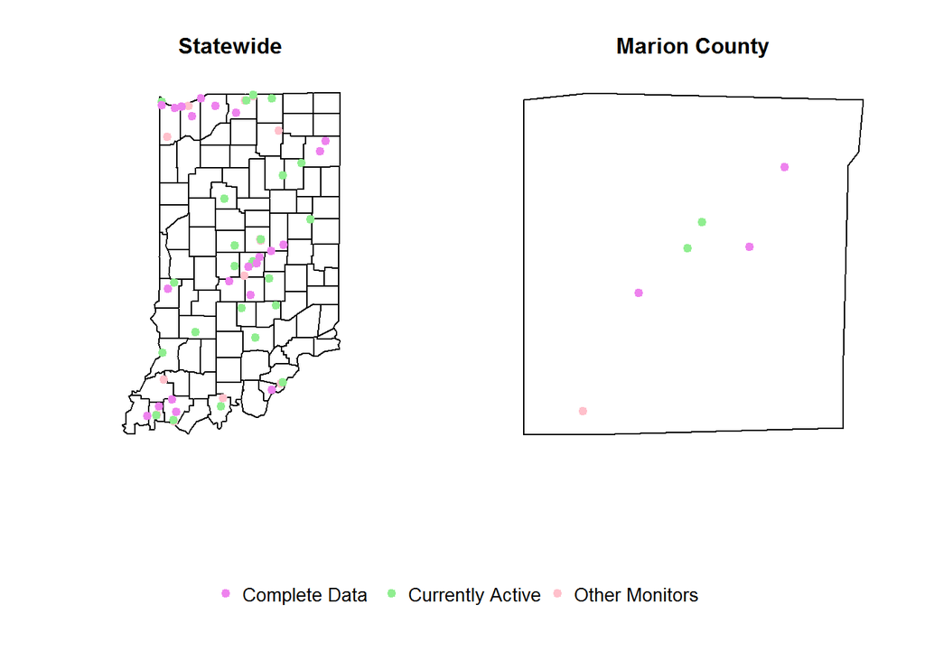

### Sulfur Dioxide (42401)

Below is a plot illustrating sulfur dioxide data coverage, by monitor, for all monitors that collected sulfur dioxide data during the period of interest.

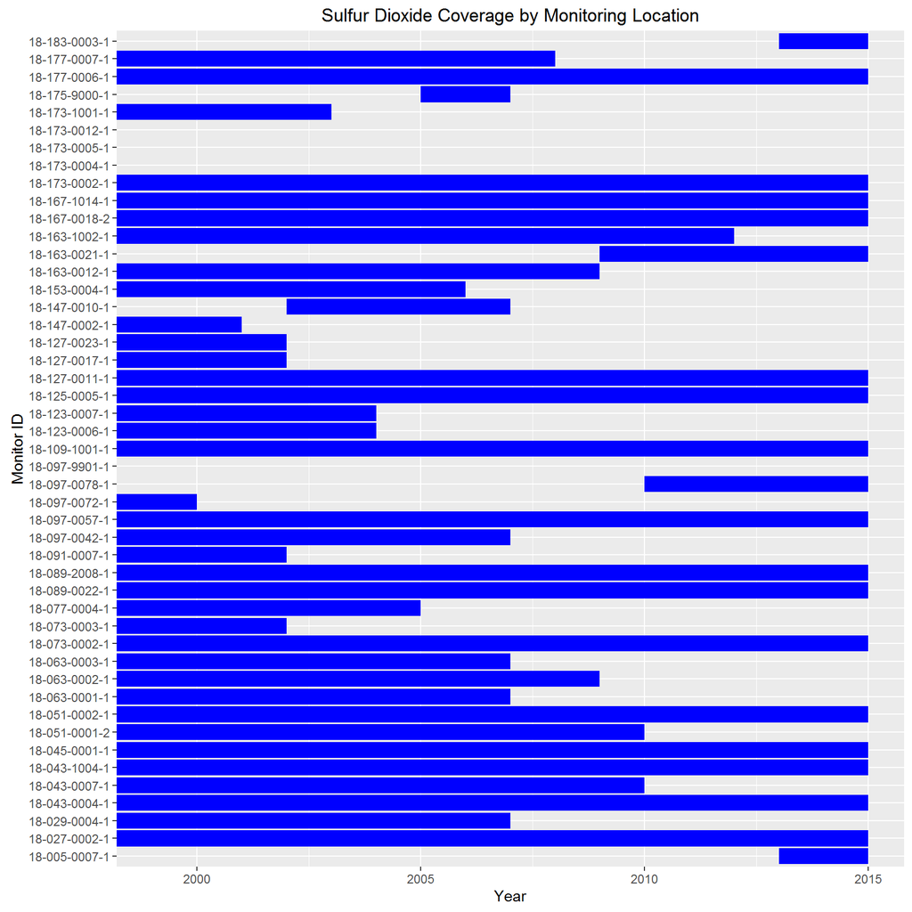

Many EPA air pollutant monitors are placed relative to specific sources and so are not representative of general concentrations or population exposures. Below is a table showing the reported purpose of sulfur dioxide monitors in Indiana.

| Monitoring Objective | Count |
| --- | --- |
| GENERAL/BACKGROUND | 4 |
| HIGHEST CONCENTRATION | 29 |
| HIGHEST CONCENTRATION; POPULATION EXPOSURE | 7 |
| POPULATION EXPOSURE | 2 |
| POPULATION EXPOSURE; UPWIND BACKGROUND | 1 |
| SOURCE ORIENTED | 1 |
| UNKNOWN | 3 |

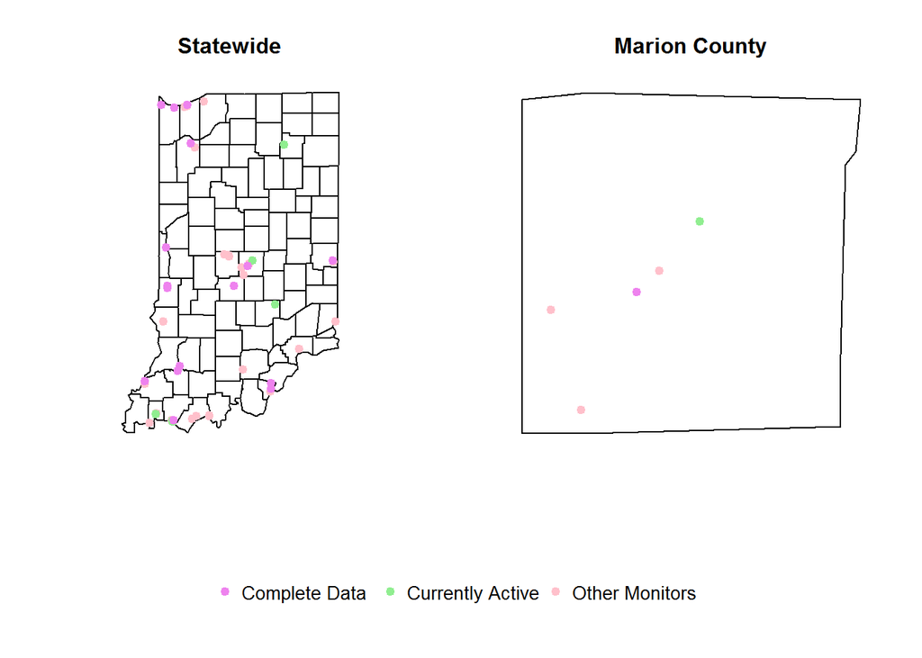

### Nitrogen Dioxide (42602)

There are 14 nitrogen dioxide monitors in Indiana that have been active at some point between 1999 and 2015. Of these, 7 were active as of the end of 2015 and 1 have been active during the entire period covered by this project (1999-2015).

Below is a plot illustrating nitrogen dioxide data coverage, by monitor, for all monitors that collected nitrogen dioxide data during the period of interest.

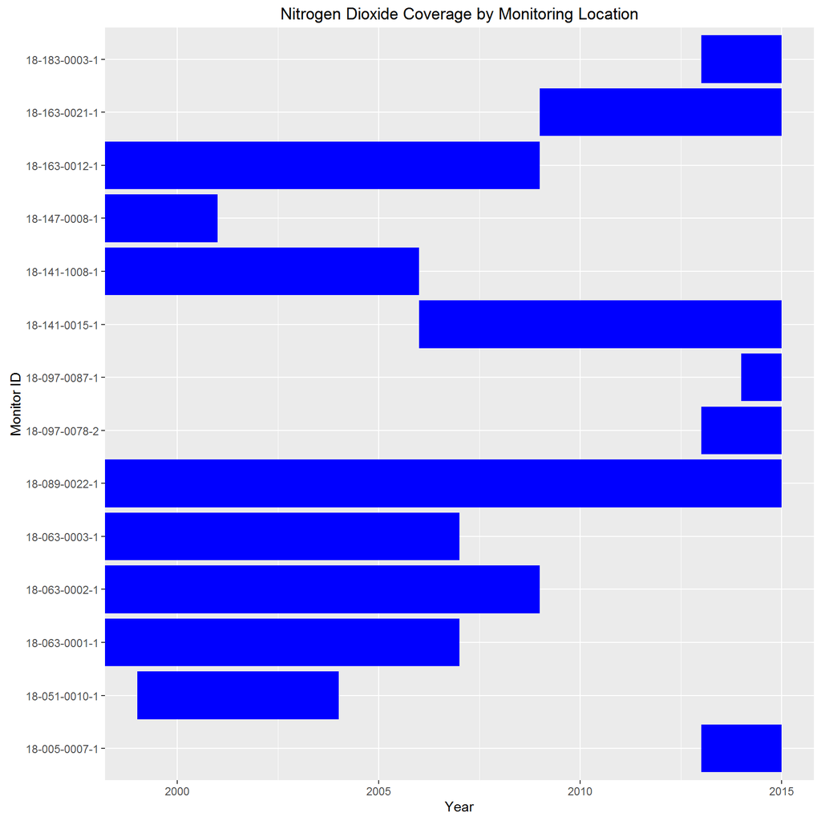

Many EPA air pollutant monitors are placed relative to specific sources and so are not representative of general concentrations or population exposures. Below is a table showing the reported purpose of nitrogen dioxide monitors in Indiana.

| Monitoring Objective | Count |
| --- | --- |
| GENERAL/BACKGROUND | 2 |
| HIGHEST CONCENTRATION | 3 |
| HIGHEST CONCENTRATION; POPULATION EXPOSURE | 4 |
| POPULATION EXPOSURE | 3 |
| UNKNOWN | 2 |

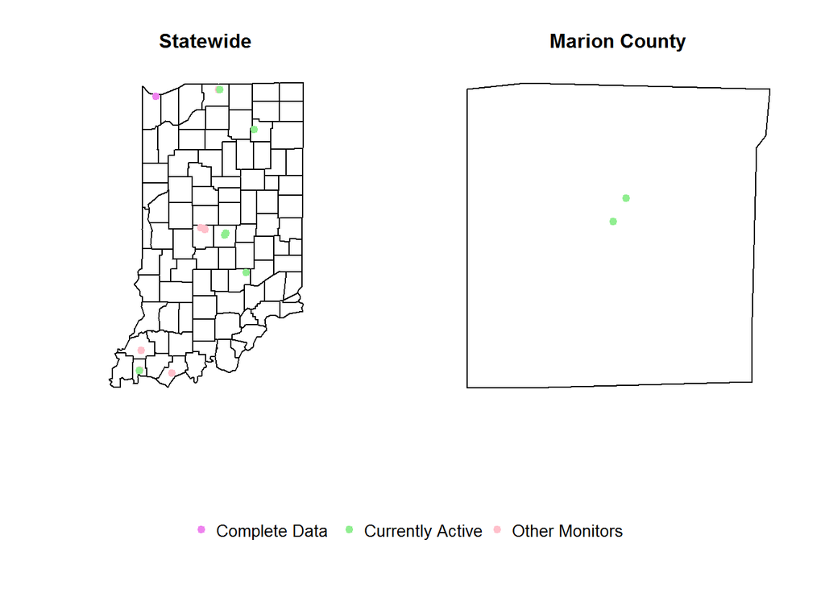

### Particulate Matter (<2.5um) (88101)

There are 99 particulate matter (<2.5um) monitors in Indiana that have been active at some point between 1999 and 2015. Of these, 61 were active as of the end of 2015 and 16 have been active during the entire period covered by this project (1999-2015).

Below is a plot illustrating particulate matter (<2.5um) data coverage, by monitor, for all monitors that collected particulate matter (<2.5um) data during the period of interest.

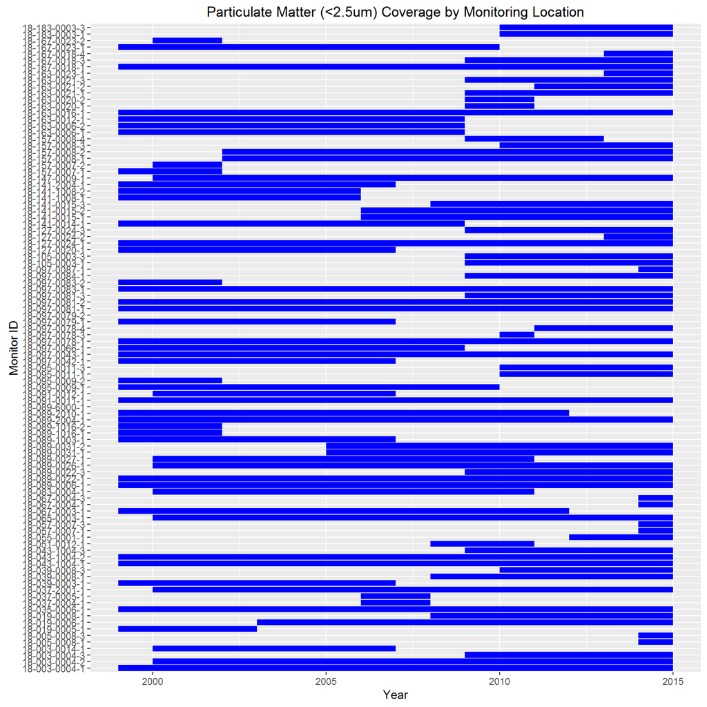

Many EPA air pollutant monitors are placed relative to specific sources and so are not representative of general concentrations or population exposures. Below is a table showing the reported purpose of particulate matter (<2.5um) monitors in Indiana.

| Monitoring_Objective | Count |
| --- | --- |
| GENERAL/BACKGROUND | 2 |
| GENERAL/BACKGROUND; POPULATION EXPOSURE; UPWIND BACKGROUND | 1 |
| GENERAL/BACKGROUND; UPWIND BACKGROUND | 1 |
| HIGHEST CONCENTRATION; POPULATION EXPOSURE | 39 |
| HIGHEST CONCENTRATION; POPULATION EXPOSURE; QUALITY ASSURANCE | 3 |
| HIGHEST CONCENTRATION; POPULATION EXPOSURE; SOURCE ORIENTED | 3 |
| HIGHEST CONCENTRATION; REGIONAL TRANSPORT | 2 |
| POPULATION EXPOSURE | 36 |
| POPULATION EXPOSURE; QUALITY ASSURANCE | 7 |
| POPULATION EXPOSURE; REGIONAL TRANSPORT | 2 |
| POPULATION EXPOSURE; SOURCE ORIENTED | 2 |
| UPWIND BACKGROUND | 1 |

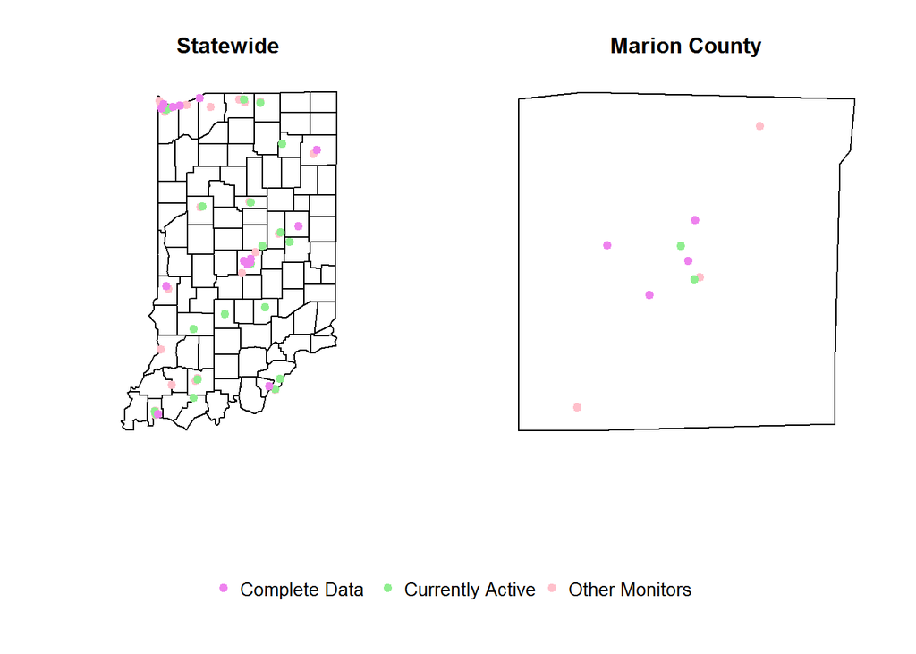

### Meteorology (various)

There are 147 meteorology monitors in Indiana that have been active at some point between 1999 and 2015. Of these, 70 were active as of the end of 2015 and 29 have been active during the entire period covered by this project (1999-2015).

Below is a plot illustrating meteorology data coverage, by monitor, for all monitors that collected meteorology data during the period of interest.

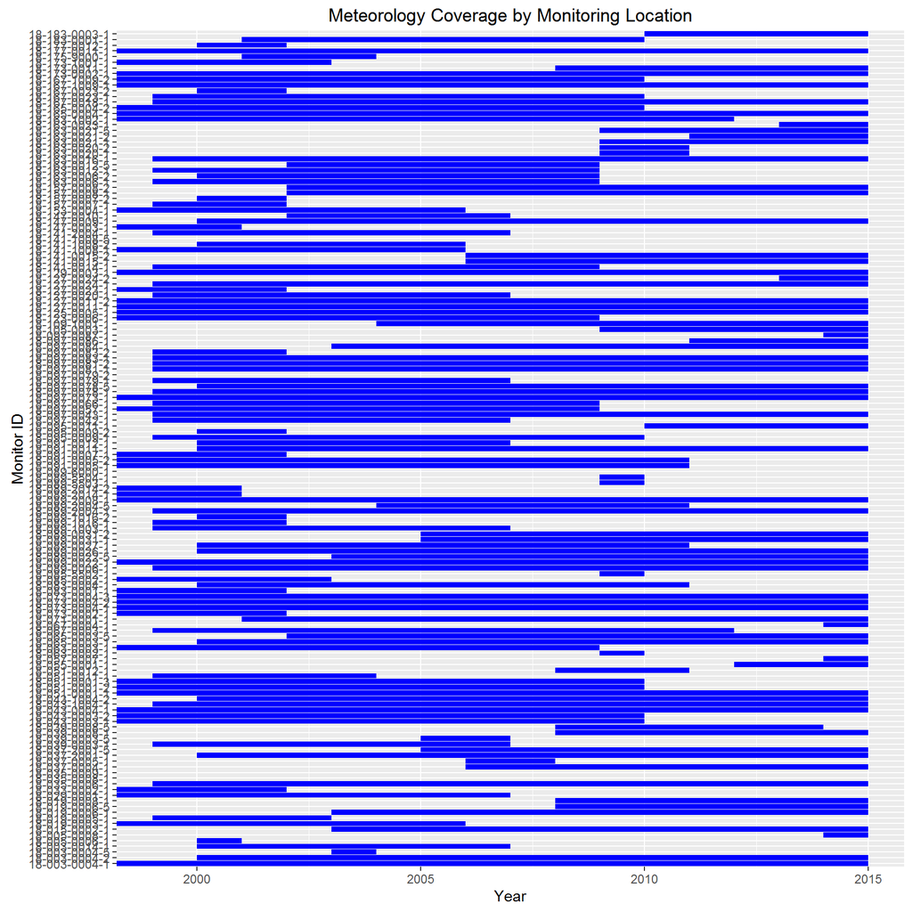

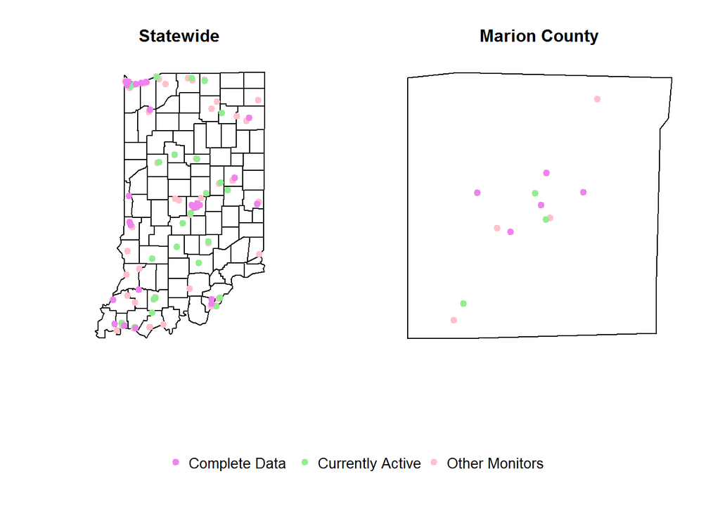